# Integrating COVID Models at Different Scales for Infection Risk Estimation

COVID-19 infections result from interactions that happen at multiple spatial and temporal scales. When working at population level spatial and temporal scales, it is feasible to model disease transmission systems using systems of ordinary differential equations. As spatial and temporal scales become smaller, the structure of social and physical interactions become more influential and stochastic events become more important. Appropriately integrating the interactions between processes that occur across spatial and temporal scales is essential for simulating systems of disease transmission and understanding infection risk.

We have developed a simulation engine that is capable of integrating a spatially explicit COVID-19 case estimation technique at the county scale with institution level disease transmission at a “building” scale. The case estimation technique takes into account location specific factors around infection control and population level movement to estimate disease burden in a given location. The institution level model uses a multigraph to integrate social and spatial contact networks under various hazard reduction strategies at two different time scales. This allows us to model individual level interactions in the local context of the COVID-19 pandemic.

```
## [1] "infected"    "recovered"   "susceptible" "leave"
```

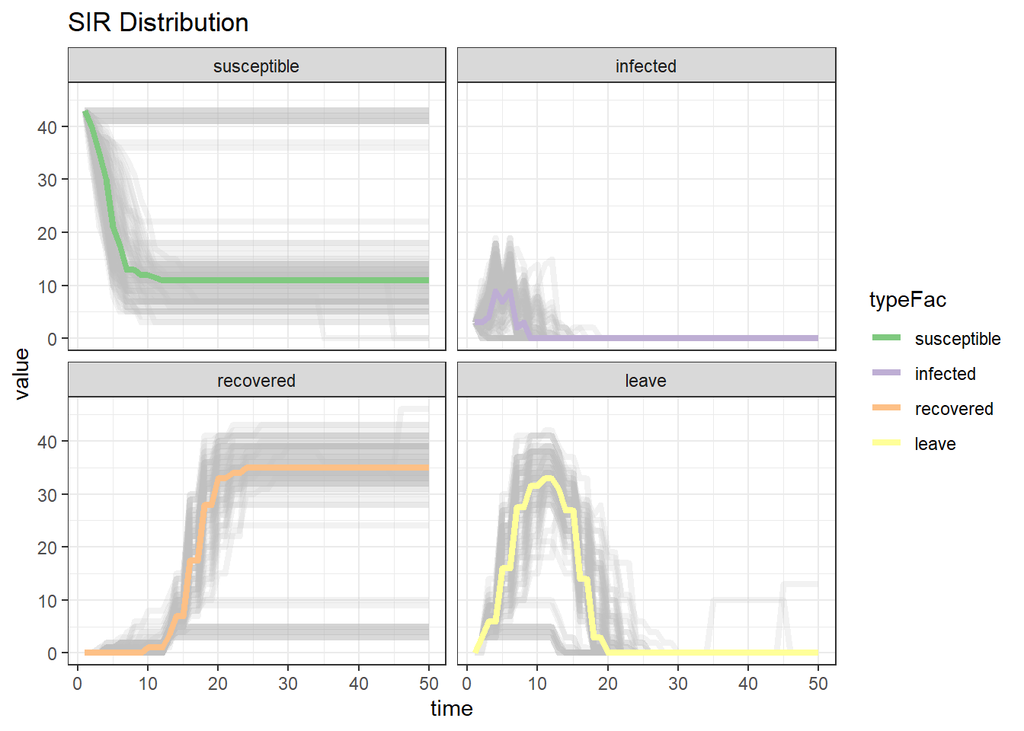